# Exploratory Data Analysis: Demographics, Housing and COVID-19

Christina Kim

10/4/2020

## Summary Data Review

```
## 'data.frame':    58 obs. of  71 variables:
##  $ countyid                                                               : int  6001 6003 6005 6007 6009 6011 6013 6015 6017 6019 ...
##  $ countyname                                                             : chr  "Alameda" "Alpine" "Amador" "Butte" ...
##  $ county_pop2019                                                         : int  1671329 1129 39752 219186 45905 21547 1153526 27812 192843 999101 ...
##  $ female                                                                 : int  848082 520 18114 110713 23058 10572 589339 12626 96685 500453 ...
##  $ male                                                                   : int  823247 609 21638 108473 22847 10975 564187 15186 96158 498648 ...
##  $ american_indian_or_alaska_native                                       : int  5448 248 741 4020 750 322 4282 2305 1870 7141 ...
##  $ asian_or_pacific_islander                                              : int  565333 18 744 12220 959 361 224442 931 10857 108435 ...
##  $ black_or_african_american                                              : int  185058 19 1173 5322 656 321 111368 1106 2410 50814 ...
##  $ hispanic_or_latino                                                     : int  373055 139 5753 37731 5967 13018 300420 5596 25378 537180 ...
##  $ white                                                                  : int  542435 705 31341 159893 37573 7525 513014 17874 152328 295531 ...
##  $ estimate_housing_occupancy_total_housing_units_occupied_housing_units  : int  585632 NA NA 77651 NA NA 399792 NA 74216 315974 ...
##  $ percent_housing_occupancy_total_housing_units_occupied_housing_units   : num  0.94 NA NA 0.901 NA NA 0.955 NA 0.81 0.939 ...
##  $ estimate_housing_occupancy_total_housing_units_vacant_housing_units    : int  37325 NA NA 8561 NA NA 18904 NA 17446 20505 ...
##  $ percent_housing_occupancy_total_housing_units_vacant_housing_units     : num  0.06 NA NA 0.099 NA NA 0.045 NA 0.19 0.061 ...
```

[output cut: 57 more lines]

```
##    countyid   countyname county_pop2019 female   male
## 1      6001      Alameda        1671329 848082 823247
## 2      6003       Alpine           1129    520    609
## 3      6005       Amador          39752  18114  21638
## 4      6007        Butte         219186 110713 108473
## 5      6009    Calaveras          45905  23058  22847
## 6      6011       Colusa          21547  10572  10975
## 7      6013 Contra Costa        1153526 589339 564187
## 8      6015    Del Norte          27812  12626  15186
## 9      6017    El Dorado         192843  96685  96158
## 10     6019       Fresno         999101 500453 498648
##    american_indian_or_alaska_native asian_or_pacific_islander
## 1                              5448                    565333
## 2                               248                        18
## 3                               741                       744
```

[output cut: 546 more lines]

There is a slight discrepancy between 2019 and 2020 population numbers but generally they are in the same ballpark.

```
##      countyname county_pop2019 county_pop_2020
## 1       Alameda        1671329         1685886
## 2        Alpine           1129            1117
## 3        Amador          39752           38531
## 4         Butte         219186          217769
## 5     Calaveras          45905           44289
## 6        Colusa          21547           22593
## 7  Contra Costa        1153526         1160099
## 8     Del Norte          27812           27558
## 9     El Dorado         192843          193098
## 10       Fresno         999101         1032227
```

County population varies quite a bit with Los Angeles county being much larger in population than any other counties in the state.

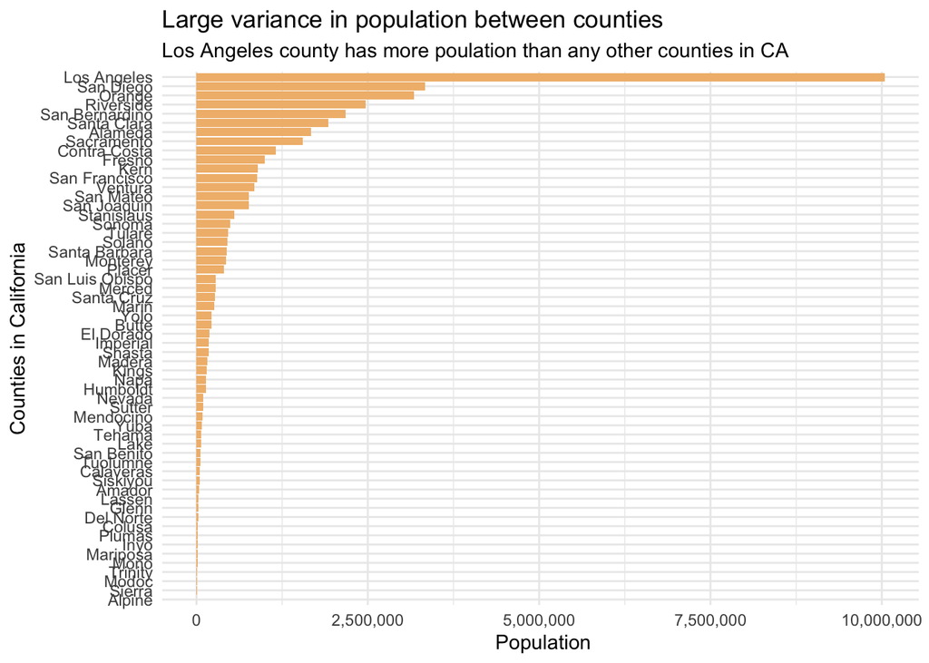

### What is the demographics makeup in California?

```
## # A tibble: 58 x 2
## # Rowwise:
##    countyname   sum_races
##    <chr>            <dbl>
##  1 Alameda           1
##  2 Alpine            1.00
##  3 Amador            1.00
##  4 Butte             1.00
##  5 Calaveras         1.00
##  6 Colusa            1.00
##  7 Contra Costa      1
##  8 Del Norte         1.
##  9 El Dorado         1.00
## 10 Fresno            1.
## # … with 48 more rows
```

With the esception of a handful of counties, majority have a roughly even split between percent male and percent female residents.

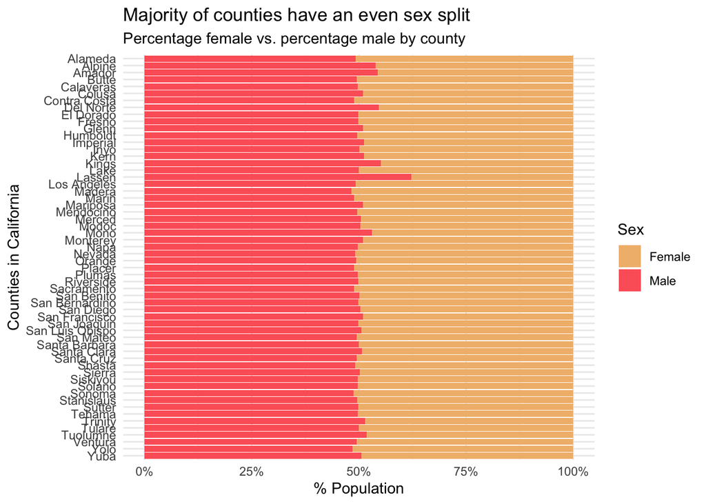

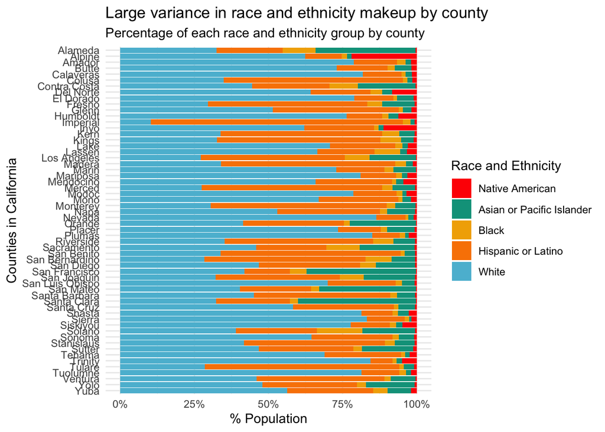

### How does the housing situation vary by county?

Note: The housing data is not available for all counties, and the counties without data were omitted.

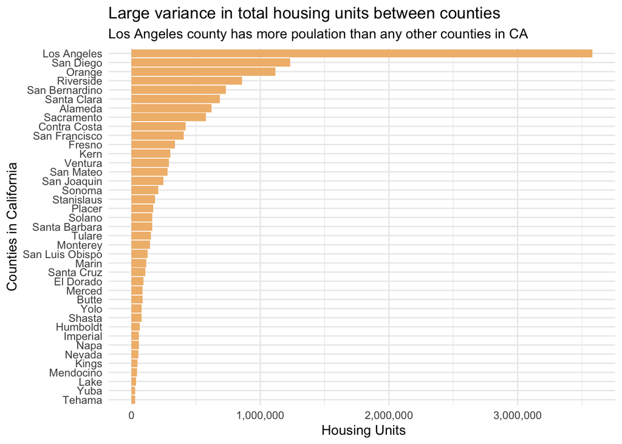

Majority of the housing units are relatively new across most of the counties. San Francisco and LA counties, however, have relatively more of older housing units than other counties.

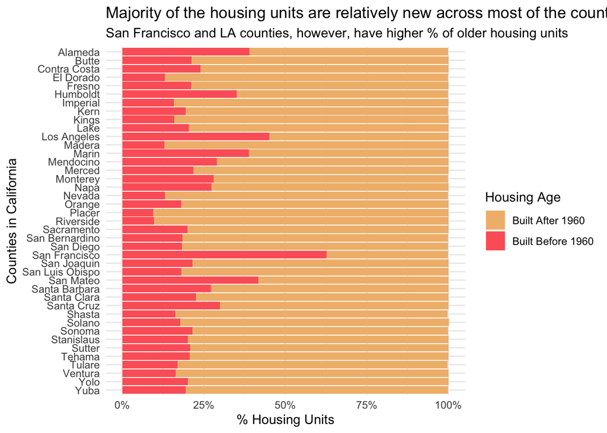

The number of occupants per room within a house is dominantly 1 or less across all counties. A few counties, e.g., Monterey, have a higher percentage of housing units where the occupants per room is greater than 1, signaling a more populated housing environment.

Note: Occupants per room columns are formatted as characters.

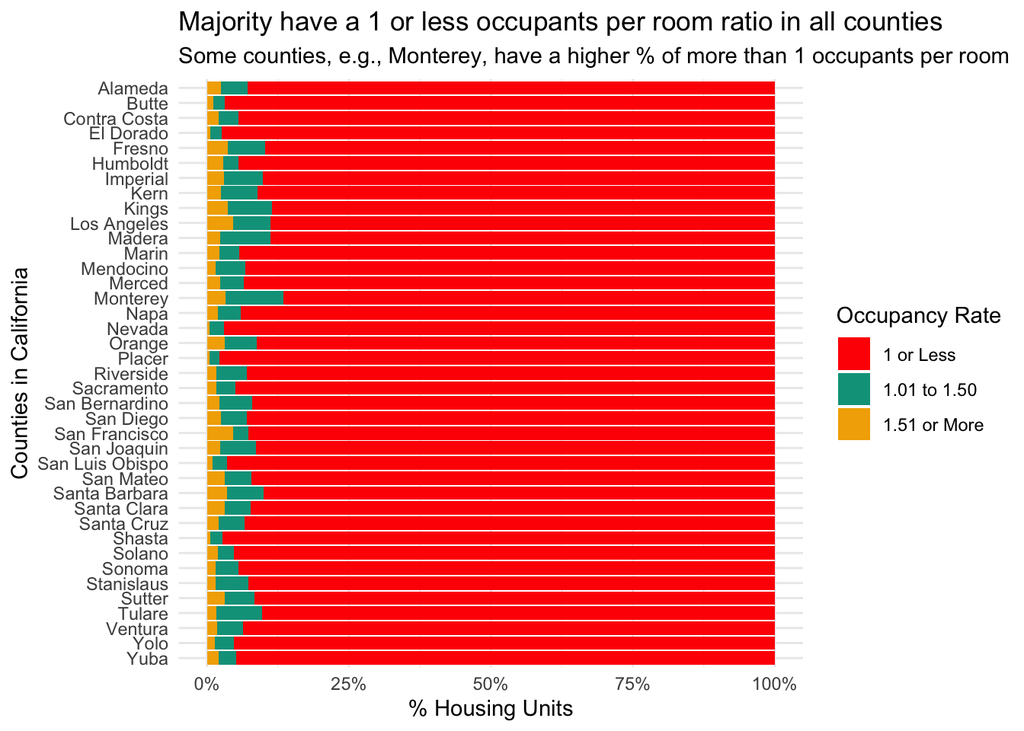

### COVID-19

Surprisingly, some of the top counties by COVID confirmed cases and deaths per 100K are not the most-populated counties. Furthermore, ranking of confimed cases and deaths did not always align, e.g, LA county had the 9th highest number of confirmed cases per 100K but 3rd highest number of deaths from COVID, signaling either disparity in access to testing or a challenge with treating confirmed patients.

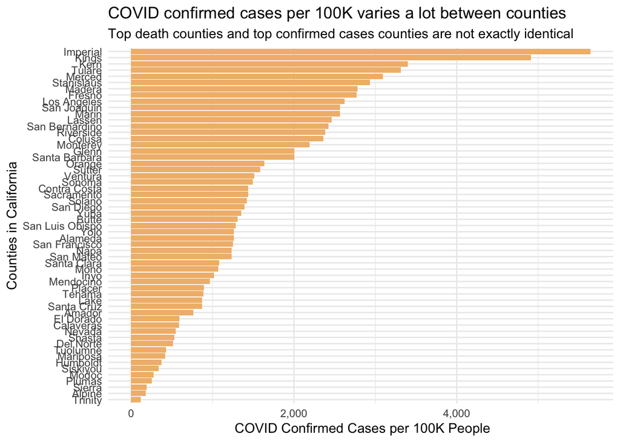

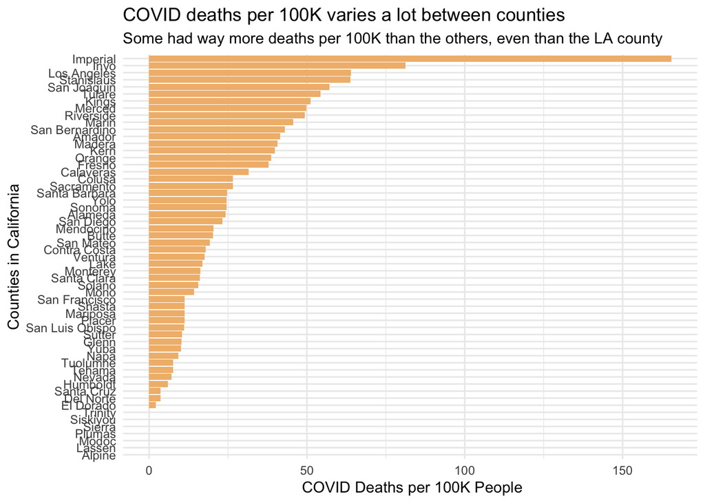